# Coursera Capstone Project - Week 2 Milestone Report

C. Roelofs

2-8-2017

# Introduction

This is the first milestone report for the Coursera Data Science Capstone project. The goal of the project is to build a predictive text model based on a database of the English language. The data base consists of texts from blogs, news papers and tweets.

In this report I will load and get to know the data. Also, I will start with some data cleaning to get familiar with the text mining tools in R. Questions I will address in this report are:

- Some words are more frequent than others - what are the distributions of word frequencies?
- What are the frequencies of 2-grams and 3-grams in the dataset?
- How many unique words do you need in a frequency sorted dictionary to cover 50% of all word instances in the language? 90%?

# Summary of the data

The data is downloaded from the [Coursera Link](https://d396qusza40orc.cloudfront.net/dsscapstone/dataset/Coursera-SwiftKey.zip), on [this](https://web-beta.archive.org/web/20160930083655/http://www.corpora.heliohost.org/aboutcorpus.html) website you can find more information about the corpora (text files).

This is very brief summary of the data:

```
   source total_lines total_words avg_words_per_line
1   Blogs      899288    38222279               42.5
2    News       77259     2748071               35.6
3 Twitter     2360148    30433285               12.9
```

Note that this summary really overestimates the number of English words, as it just counts the number of spaces (+ one for the first word). So any punctuation between spaces count as another word (for example in ‘hi !’ counts as 2 words).

# Cleaning data

To determine word frequencies and those of the bi- and trigrams, we first need to do some data cleaning. This is just to remove puntuation, numbers, etc. To get an idea of the data I select a random subset of each of the files, so the the processing does not take too long. I will take 10% of the total number of files for analysis.

Than I remove any characters that are not part of the Latin or Punctuation unicode blocks. This removes the Chinese, Ethiopian and other non-latin characters. Next data is transformed so the texts only contain lower case characters, no number or punctuations and no extra white spaces. This is done to get rid of the difference between ‘hi!’, ‘HI’ and ‘Hi’ for example. These are all transformed to ‘hi’.

One task of the capstone project was to do something about swear words, as you do not want those in your predicted texts. I do not remove swear words from the data sets as it probably make the prediction algorithm less accurate. However, to keep it out of the prediction we can filter the output of the the text predictor using the list on [this](https://www.frontgatemedia.com/a-list-of-723-bad-words-to-blacklist-and-how-to-use-facebooks-moderation-tool/) website, which I tweaked a bit as it was very prudish. This way, if someone enters a swear word, the next word can still be predicted.

Next will tokenize the data into words (also called ‘unigrams’), bigrams (sentences of 2 words) and trigrams (3 words) to find out which words, bigrams and trigrams are most common in the data. We could also zoom in on differences between news, blog and twitter data seperately. To make ‘correct’ bigrams and trigrams, I first tokenize the texts into sentences. This will also reduce the number of bigrams and trigrams, and these extra n-grams would be very unlikely (rare) anyway.

# Most frequent words

First, let’s have a look at the most frequent words in the texts:

Top 20 words in news texts

| words | word_frequency | bigrams | bigram_frequency | trigrams | trigram_frequency |
| --- | --- | --- | --- | --- | --- |
| the | 15140 | of_the | 1394 | one_of_the | 103 |
| to | 6971 | in_the | 1346 | a_lot_of | 95 |
| and | 6772 | to_the | 642 | as_well_as | 55 |
| a | 6742 | on_the | 582 | the_end_of | 52 |
| of | 5867 | for_the | 557 | according_to_the | 47 |
| in | 5143 | at_the | 479 | in_the_first | 46 |
| for | 2687 | in_a | 400 | going_to_be | 44 |
| that | 2527 | and_the | 392 | out_of_the | 43 |
| is | 2148 | to_be | 321 | of_the_year | 42 |
| on | 2105 | with_the | 312 | some_of_the | 41 |
| said | 1992 | from_the | 288 | it_was_a | 38 |
| with | 1963 | with_a | 260 | part_of_the | 34 |
| was | 1829 | he_said | 259 | the_united_states | 34 |
| he | 1790 | of_a | 259 | to_be_a | 33 |
| at | 1685 | as_a | 258 | the_first_time | 33 |
| it | 1632 | for_a | 238 | end_of_the | 30 |
| as | 1465 | is_a | 234 | in_the_second | 29 |
| his | 1253 | by_the | 212 | at_the_end | 29 |
| i | 1219 | it_was | 210 | be_able_to | 29 |
| but | 1193 | the_first | 208 | for_the_first | 26 |

Top 20 words in blogs texts

| words | word_frequency | bigrams | bigram_frequency | trigrams | trigram_frequency |
| --- | --- | --- | --- | --- | --- |
| the | 185703 | of_the | 18661 | one_of_the | 1429 |
| and | 109515 | in_the | 15534 | a_lot_of | 1288 |
| to | 106173 | to_the | 8585 | the_end_of | 703 |
| a | 89570 | on_the | 7415 | to_be_a | 669 |
| of | 87433 | to_be | 6762 | it_was_a | 643 |
| i | 77036 | and_the | 5861 | some_of_the | 640 |
| in | 59261 | for_the | 5814 | as_well_as | 639 |
| that | 45886 | at_the | 4947 | i_want_to | 628 |
| is | 43278 | and_i | 4864 | out_of_the | 626 |
| it | 40222 | i_was | 4833 | a_couple_of | 609 |
| for | 36470 | i_have | 4786 | be_able_to | 603 |
| you | 29480 | it_was | 4708 | this_is_a | 543 |
| with | 28450 | it_is | 4704 | the_fact_that | 540 |
| was | 27523 | in_a | 4577 | i_have_a | 534 |
| on | 27209 | is_a | 4525 | there_is_a | 528 |
| my | 26573 | with_the | 4469 | going_to_be | 525 |
| this | 25837 | i_am | 4299 | i_have_been | 525 |
| as | 22477 | from_the | 3886 | i_have_to | 502 |
| have | 21849 | that_i | 3737 | part_of_the | 493 |
| be | 20845 | of_a | 3360 | the_rest_of | 486 |

Top 20 words in twitter texts

| words | word_frequency | bigrams | bigram_frequency | trigrams | trigram_frequency |
| --- | --- | --- | --- | --- | --- |
| the | 93017 | in_the | 7735 | thanks_for_the | 2400 |
| to | 79025 | for_the | 7363 | looking_forward_to | 896 |
| i | 72703 | of_the | 5532 | thank_you_for | 843 |
| a | 60682 | on_the | 4794 | i_love_you | 814 |
| you | 55165 | to_be | 4742 | i_want_to | 772 |
| and | 43688 | thanks_for | 4374 | for_the_follow | 758 |
| for | 38551 | to_the | 4244 | can’t_wait_to | 732 |
| in | 37800 | at_the | 3836 | going_to_be | 721 |
| of | 35834 | i_love | 3527 | to_be_a | 605 |
| is | 35625 | going_to | 3411 | i_need_to | 602 |
| it | 29697 | have_a | 3386 | a_lot_of | 589 |
| my | 29401 | thank_you | 3304 | i_have_a | 578 |
| on | 27549 | if_you | 3287 | one_of_the | 559 |
| that | 23387 | i_have | 3111 | have_a_great | 536 |
| me | 20257 | i_am | 3044 | to_see_you | 502 |
| at | 18872 | for_a | 2971 | i_have_to | 493 |
| be | 18732 | to_get | 2748 | i’m_going_to | 474 |
| your | 17121 | is_a | 2672 | is_going_to | 436 |
| with | 17038 | to_see | 2644 | to_go_to | 429 |
| have | 16975 | i_think | 2612 | for_the_rt | 426 |

As we can see, most of these are so called stop words or empty words (they have no meaning). One can remove these to get to know more about the context or meaning of the texts. However, for text prediction it is probably better to leave them in.

For Twitter texts we find that the use of stop words is much less, probably because of the charcter limit on tweets. It is funny how the most frequent trigram for both news and blogs is ‘one of the’ while for twitter it is ‘thanks for the’.

# Coverage

The model that most closely resembles the text it predicts from will take all words in that text, however this is very memory inefficient. So, we would like to know many unique words are needed in a frequency sorted dictionary to cover 50% or 90% of all word instances in the language. For this I will no longer treat the 3 text sources seperately, but as one (subset of) database of the English language.

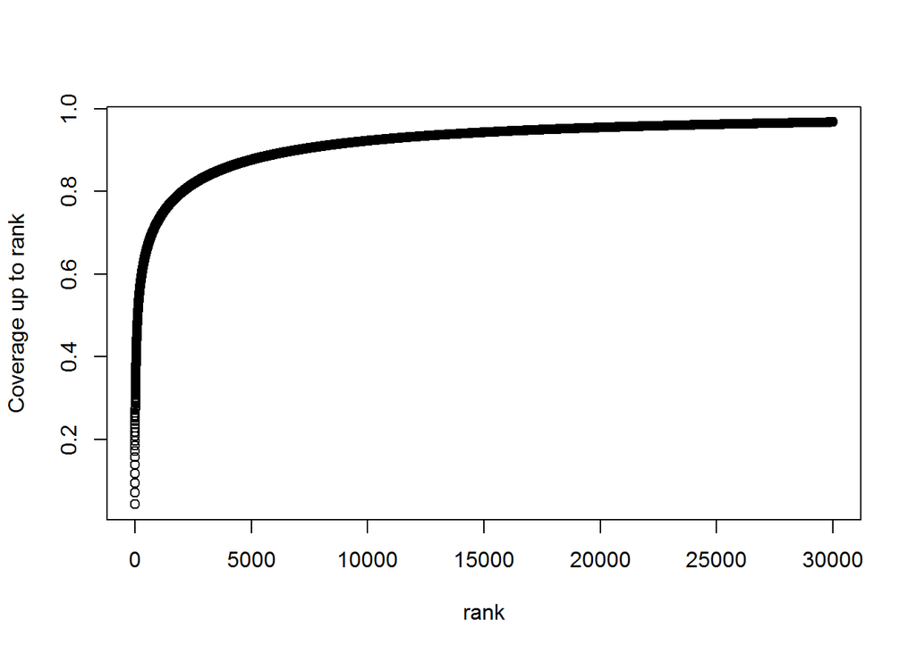

We could also have a look the distribution of the counts of the words. As the highest count is almost 300000 and the lowest 1, I will take the log of the count before making a histogram.

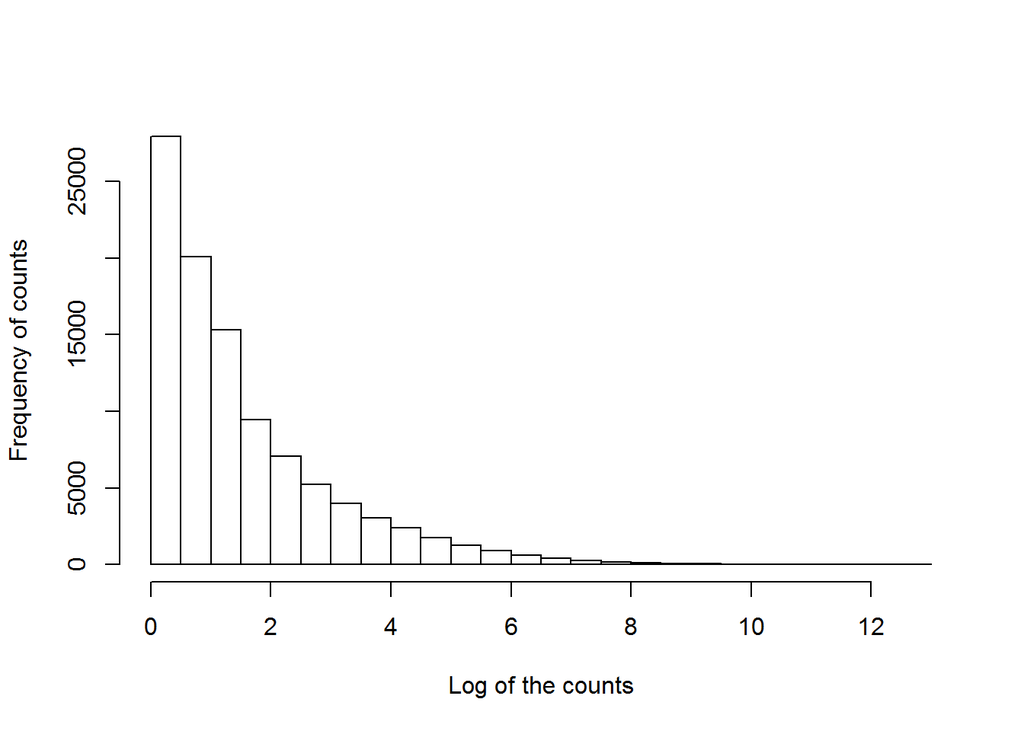

From the plot we see that there are a lot of words which are not that frequent and a small number of words that are very frequent. This explains why you need such a small number of words to cover almost all of the text.

# Ideas to develop N-gram model

From this report I will take the following steps for creating the n-grams:

- Profane words are removed at output and not form the training texts to make sure we predict the right next word when such word is used, but do not recommend it as the next word.
- Creating features from the texts by first tokenizing the text to sentences, to avoid creating bigrams and trigrams which stretch two sentences.
- Keep stop words and do not stem words, as they are part of the sentence and grammer of the language. However, the vocabulary does increase a lot if we do not stem so we need to think about some smart way of storing data.

From the amount of time just reading in the data and do some simple calculations:

- Probably create a lookup table to get probabilities of word occurances in a fast way
- Keeping only the top x words/ngrams (as we saw we need quite a small number to reach 90% coverage), to reduce the number of words in the vocabulary so loading and using the model will be more memory friendly and much faster.

For actual development of the model:

- Efficiently storing the model can probably be done use a Markov chain.
- The most simple model could just be something like Katz’ Backoff algorithm, which falls back to (n-1)-grams if the n-gram wasn’t seen. So if sequence ‘xy’ is typed, I pick the most probable trigram starting with ‘xy’. If there no such trigram I will pick the most probably bigram starting with ‘y’. If there are no bigrams that fit this criterium I will just pick the most frequent word of the corpus.
- We might want an algorithm to ‘smooth’ the probabilities of these. We did not see those in the data (or left them out in favor of memory and runtime) but that does not mean that their probability is zero. There are several smoothing algorithms that take care of this, such as Laplace smoothing, Good-Turing, Kneser-Ney and Witten-Bell. Katz’ Backoff uses Good-Turing discounting.

These are things I will study a bit more in depth to develop a first version of the text prediction algorithm. Some resources which are very helpful are:

- [Wikipedia Markov Chain](https://en.wikipedia.org/wiki/Markov_chain)
- [Lecture notes on smoothing](https://nlp.stanford.edu/~wcmac/papers/20050421-smoothing-tutorial.pdf)
- [Some more lecture notes on smoothing and backoff](http://www.cs.cornell.edu/courses/cs4740/2014sp/lectures/smoothing+backoff.pdf)
- [Wikipedia Good-Turing smoothing](https://en.wikipedia.org/wiki/Good%E2%80%93Turing_frequency_estimation)
- [Wikipedia Katz’back-off model](https://en.wikipedia.org/wiki/Katz%27s_back-off_model)
- [Katz’s Backoff Model implementation in R](https://thachtranerc.wordpress.com/2016/04/12/katzs-backoff-model-implementation-in-r/)
- [NLP course notes](http://files.asimihsan.com/courses/nlp-coursera-2013/notes/nlp.html) (especially for Markov chains)
- [Speech and Language Processing book by Dan Jurafsky and James H. Martin](https://web.stanford.edu/~jurafsky/slp3/)

# Appendix

R code used in this report

```r
knitr::opts_chunk$set(echo = FALSE)
knitr::opts_chunk$set(comment = NA)
library(quanteda)
# The data can be loaded using the readLines command in R.
blog_texts <- readLines('data/en_US/en_US.blogs.txt', encoding = 'UTF-8', skipNul = TRUE)
twitter_texts <- readLines('data/en_US/en_US.twitter.txt', encoding = 'UTF-8', skipNul = TRUE)
news_texts <- readLines('data/en_US/en_US.news.txt', encoding = 'UTF-8', skipNul = TRUE)

# get some stats of the data
total_lines <- c(length(blog_texts), length(news_texts), length(twitter_texts))
total_words <- c(sum(sapply(gregexpr("\\W+", blog_texts),   length)) + 1,
                 sum(sapply(gregexpr("\\W+", news_texts),   length)) + 1,
                 sum(sapply(gregexpr("\\W+", twitter_texts),   length)) + 1)
avg_words_per_line <- total_words/total_lines


data.frame(source = c("Blogs", "News", "Twitter"), total_lines, total_words, avg_words_per_line = round(avg_words_per_line,1))

# subset data
set.seed(1234)
p = 0.1
subset_blog <- sample(blog_texts, length(blog_texts)*p)
subset_news <- sample(news_texts, length(news_texts)*p)
subset_twitter <- sample(twitter_texts, length(twitter_texts)*p)
rm(blog_texts,news_texts,twitter_texts)

# function that returns a list of 'cleaned' tokens of the text files for further analysis
clean_tokens <- function(texts){
  tokens_texts <- toLower(
    tokenize(texts, remove_numbers = TRUE, remove_punct = TRUE,
             remove_symbols = TRUE, remove_twitter = TRUE),
    keep_acronyms = TRUE)
  return(tokens_texts)}

# function return a list of sentences containing only latin and punctuation characters
clean_sentence <- function(texts){
  sentences <- tokenize(texts, what = 'sentence')
  sentences <- as.tokenizedTexts(lapply(sentences, gsub, replacement = "", pattern = "[^(\\p{Latin}|\\p{P}|\\p{S}| )]", perl = TRUE))
  sentences <- as.tokenizedTexts(lapply(sentences, stringi::stri_replace, replacement = "" ,regex = "^\xf8"))
  return(sentences)
}

# make (more or less clean) sentences
blogs_sentences <- clean_sentence(subset_blog)
news_sentences <- clean_sentence(subset_news)
twitter_sentences <- clean_sentence(subset_twitter)

# tokenize sentences
blogs_tokens <- clean_tokens(unlist(blogs_sentences))
news_tokens <- clean_tokens(unlist(news_sentences))
twitter_tokens <- clean_tokens(unlist(twitter_sentences))
rm(blogs_sentences, news_sentences, twitter_sentences)
# make uni- bi- and trigrams
news_ngrams = list()
blogs_ngrams = list()
twitter_ngrams = list()
n = list('unigram' = 1, 'bigram' = 2, 'trigram' = 3)
for(i in n){
  news_ngrams[[names(n[i])]] = tokens_ngrams(news_tokens, n = n[[i]])
  blogs_ngrams[[names(n[i])]] = tokens_ngrams(blogs_tokens, n = n[[i]])
  twitter_ngrams[[names(n[i])]] = tokens_ngrams(twitter_tokens, n = n[[i]])
}

# show top 20 features for ngrams in ngram_list
create_top_words_df <- function(ngram_list, top=20){
  word_freq = topfeatures(dfm(ngram_list[[1]]),top)
  bigram_freq = topfeatures(dfm(ngram_list[[2]]),top)
  trigram_freq = topfeatures(dfm(ngram_list[[3]]),top)

  df <- data.frame(
    words = names(word_freq),
    word_frequency = word_freq,
    bigrams = names(bigram_freq),
    bigram_frequency = bigram_freq,
    trigrams = names(trigram_freq),
    trigram_frequency = trigram_freq
  )

  rownames(df) <- NULL
  df
}

knitr::kable(create_top_words_df(news_ngrams), caption = "Top 20 words in news texts")
knitr::kable(create_top_words_df(blogs_ngrams), caption = "Top 20 words in blogs texts")
knitr::kable(create_top_words_df(twitter_ngrams), caption = "Top 20 words in twitter texts")

# make a db of all texts
# sample of all texts = just adding the three subsets.
subset_all = c(subset_blog, subset_news, subset_twitter)
tokens_all <- clean_tokens(subset_all)
dfm_all <- dfm(tokens_all)

# number of words (tokens) in the subset:
total_words_all <- sum(unlist(lapply(tokens_all,length)))
# frequency sorted dictionary of top 100000 words:
N <- 100000
dict <- topfeatures(dfm_all, N)
# plot coverage up to each rank
x <- 1:N
y <- cumsum(dict)/total_words_all
plot(x[1:30000], y[1:30000], xlab="rank", ylab="Coverage up to rank")

hist(log(dict), ylab="Frequency of counts", xlab="Log of the counts", main="")
```